# Linear Regression Data Analysis - Project 1

Nirmal Aagash C

6/10/2020

## Objective

This is a report file for using the dataset “California Housing Prices” from Kaggle. Below are some of the analysis and pre-processing that have been performed on the dataset. The below analysis lets us understand the importance of each features and the effect it has on the output. The dataset contains 20640 rows and 10 columns with the output variable as ‘median_house_value’ which determines the house price with respect to the features.

### Reading the Data

Below is the code to import tidyverse and read csv (‘California Housing Prices’) from the system

```r
library(tidyverse)
rhm <- read_csv('housing.csv')
```

The rhm tibble contains the following of 20640x10 values

```r
head(rhm)
```

```
## # A tibble: 6 x 10
##   longitude latitude housing_median_~ total_rooms total_bedrooms population
##       <dbl>    <dbl>            <dbl>       <dbl>          <dbl>      <dbl>
## 1     -122.     37.9               41         880            129        322
## 2     -122.     37.9               21        7099           1106       2401
## 3     -122.     37.8               52        1467            190        496
## 4     -122.     37.8               52        1274            235        558
## 5     -122.     37.8               52        1627            280        565
## 6     -122.     37.8               52         919            213        413
## # ... with 4 more variables: households <dbl>, median_income <dbl>,
## #   median_house_value <dbl>, ocean_proximity <chr>
```

The Columns in the dataset are “longitude” “latitude” “housing_median_age” “total_rooms” “total_bedrooms” “population” “households” “median_income” “median_house_value” “ocean_proximity”

### Pre processing of Data

The ocean_proximity column contains non-numeric values and hence we do index labeling by mapping all the unique values to numbers

```r
output_var = 1:length(unique(rhm$ocean_proximity))
names(output_var) = unique(rhm$ocean_proximity)
```

```r
output_var
```

```
##   NEAR BAY  <1H OCEAN     INLAND NEAR OCEAN     ISLAND
##          1          2          3          4          5
```

Now that the values are mapped lets add it to the rhm tibble and remove the existing non-numeric column ocean_proximity

```r
rhm$ocean_proximity_mapped = output_var[rhm$ocean_proximity]
rhm_numeric = subset(rhm, select= -c(ocean_proximity))
```

There are few NA values in the dataset and we remove it.

```r
rhm_numeric <- na.omit(rhm_numeric)
```

After removing the NA values, the dataset is reduce to 20433x10 values (Only a few of the records are removed from the dataset and assuming it doesn’t affect the performance we continue)

```r
rhm_numeric
```

```
## # A tibble: 20,433 x 10
##    longitude latitude housing_median_~ total_rooms total_bedrooms population
##        <dbl>    <dbl>            <dbl>       <dbl>          <dbl>      <dbl>
##  1     -122.     37.9               41         880            129        322
##  2     -122.     37.9               21        7099           1106       2401
##  3     -122.     37.8               52        1467            190        496
##  4     -122.     37.8               52        1274            235        558
##  5     -122.     37.8               52        1627            280        565
##  6     -122.     37.8               52         919            213        413
##  7     -122.     37.8               52        2535            489       1094
##  8     -122.     37.8               52        3104            687       1157
##  9     -122.     37.8               42        2555            665       1206
## 10     -122.     37.8               52        3549            707       1551
## # ... with 20,423 more rows, and 4 more variables: households <dbl>,
## #   median_income <dbl>, median_house_value <dbl>, ocean_proximity_mapped <int>
```

### Analysing the importance of features on the output variable

The correaltion of rhm_numeric tibble is as follows

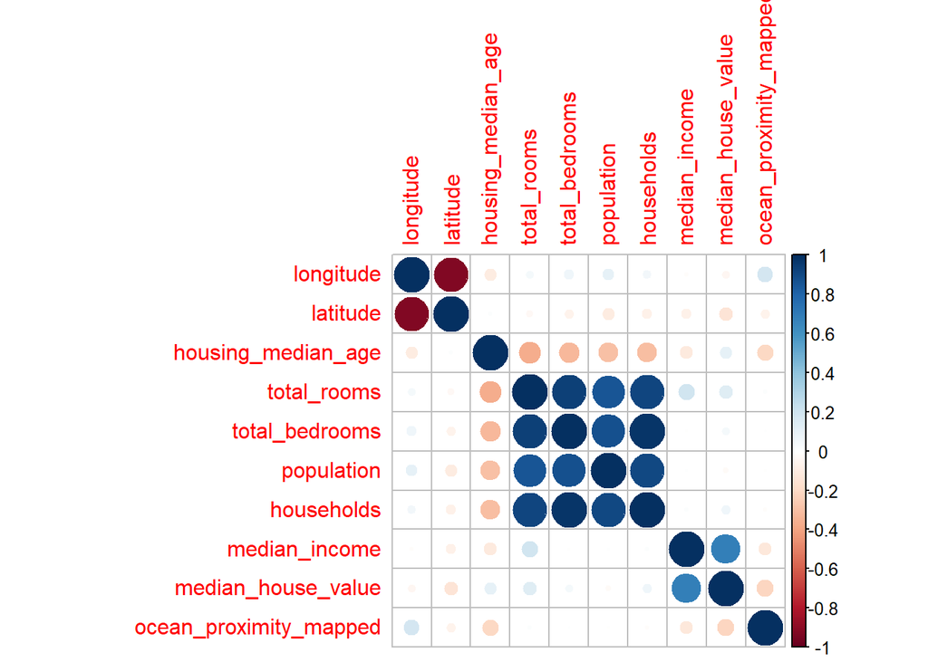

```r
require(corrplot)
corrOfRHM <- cor(rhm_numeric)
corrplot(corrOfRHM)
```

To check for the features that matter the most we could check for the absolute value of the features that are closer to 1.

```r
rhm_df <- as.data.frame(corrOfRHM)
rownames(rhm_df)[which(abs(rhm_df$median_house_value)>0.1)]
```

```
## [1] "latitude"               "housing_median_age"     "total_rooms"
## [4] "median_income"          "median_house_value"     "ocean_proximity_mapped"
```

```r
rhm_df <- as.data.frame(corrOfRHM)
rownames(rhm_df)[which(abs(rhm_df$median_house_value)>0.2)]
```

```
## [1] "median_income"          "median_house_value"     "ocean_proximity_mapped"
```

```r
rhm_df <- as.data.frame(corrOfRHM)
rownames(rhm_df)[which(abs(rhm_df$median_house_value)>0.3)]
```

```
## [1] "median_income"      "median_house_value"
```

```r
rhm_df <- as.data.frame(corrOfRHM)
rownames(rhm_df)[which(abs(rhm_df$median_house_value)>0.4)]
```

```
## [1] "median_income"      "median_house_value"
```

```r
rhm_df <- as.data.frame(corrOfRHM)
rownames(rhm_df)[which(abs(rhm_df$median_house_value)>0.5)]
```

```
## [1] "median_income"      "median_house_value"
```

By checking we could see that the variable mesian_income has very much effect on the output variable

### Linear Regression

Lets analyze the outcome of of different models by fitting with different combinations of features from the above analyzed correlation

First, include the library MASS from CRAN to use the linear model.

```r
require(MASS)
```

```r
lm.fit = lm(median_house_value~housing_median_age+ocean_proximity_mapped+median_income,longitude, data = rhm_numeric )
summary(lm.fit)
```

```
##
## Call:
## lm(formula = median_house_value ~ housing_median_age + ocean_proximity_mapped +
##     median_income, data = rhm_numeric, subset = longitude)
##
## Residuals:
##     Min      1Q  Median      3Q     Max
## -589308  -53325  -16202   35741  460462
##
## Coefficients:
##                         Estimate Std. Error t value Pr(>|t|)
## (Intercept)             26628.08    2883.40   9.235   <2e-16 ***
## housing_median_age       1567.74      46.12  33.993   <2e-16 ***
## ocean_proximity_mapped -11662.92     680.89 -17.129   <2e-16 ***
## median_income           42385.25     301.66 140.509   <2e-16 ***
## ---
## Signif. codes:  0 '***' 0.001 '**' 0.01 '*' 0.05 '.' 0.1 ' ' 1
##
## Residual standard error: 80280 on 20418 degrees of freedom
## Multiple R-squared:  0.5164, Adjusted R-squared:  0.5163
## F-statistic:  7268 on 3 and 20418 DF,  p-value: < 2.2e-16
```

```r
lm.fit2 = lm(median_house_value~housing_median_age+ocean_proximity_mapped, data = rhm_numeric)
summary(lm.fit2)
```

```
##
## Call:
## lm(formula = median_house_value ~ housing_median_age + ocean_proximity_mapped,
##     data = rhm_numeric)
##
## Residuals:
##     Min      1Q  Median      3Q     Max
## -227690  -81560  -29304   56648  349112
##
## Coefficients:
##                         Estimate Std. Error t value Pr(>|t|)
## (Intercept)            255789.61    3334.03  76.721   <2e-16 ***
## housing_median_age        600.51      63.92   9.395   <2e-16 ***
## ocean_proximity_mapped -26825.70     942.21 -28.471   <2e-16 ***
## ---
## Signif. codes:  0 '***' 0.001 '**' 0.01 '*' 0.05 '.' 0.1 ' ' 1
##
## Residual standard error: 112600 on 20430 degrees of freedom
## Multiple R-squared:  0.04906,    Adjusted R-squared:  0.04897
## F-statistic:   527 on 2 and 20430 DF,  p-value: < 2.2e-16
```

Fit the linear model for all the features

```r
lm.fit3 = lm(median_house_value~. , data = rhm_numeric)
summary(lm.fit3)
```

```
##
## Call:
## lm(formula = median_house_value ~ ., data = rhm_numeric)
##
## Residuals:
##     Min      1Q  Median      3Q     Max
## -561337  -43625  -11472   30473  804647
##
## Coefficients:
##                          Estimate Std. Error t value Pr(>|t|)
## (Intercept)            -3.508e+06  6.494e+04 -54.014  < 2e-16 ***
## longitude              -4.200e+04  7.327e+02 -57.324  < 2e-16 ***
## latitude               -4.199e+04  6.853e+02 -61.275  < 2e-16 ***
## housing_median_age      1.124e+03  4.393e+01  25.591  < 2e-16 ***
## total_rooms            -7.920e+00  7.968e-01  -9.940  < 2e-16 ***
## total_bedrooms          1.127e+02  6.931e+00  16.262  < 2e-16 ***
## population             -3.858e+01  1.084e+00 -35.580  < 2e-16 ***
## households              4.726e+01  7.543e+00   6.266 3.79e-10 ***
## median_income           4.008e+04  3.400e+02 117.902  < 2e-16 ***
## ocean_proximity_mapped -2.924e+03  6.130e+02  -4.770 1.86e-06 ***
## ---
## Signif. codes:  0 '***' 0.001 '**' 0.01 '*' 0.05 '.' 0.1 ' ' 1
##
## Residual standard error: 69530 on 20423 degrees of freedom
## Multiple R-squared:  0.6373, Adjusted R-squared:  0.6372
## F-statistic:  3988 on 9 and 20423 DF,  p-value: < 2.2e-16
```

From the above three analysis of fitting the models, we understand that the one with higher Adjusted R is lm.fit3 which considers every features.

### Plots of features with output variable

A function that iterated with the features and plots the graph against the output variable.

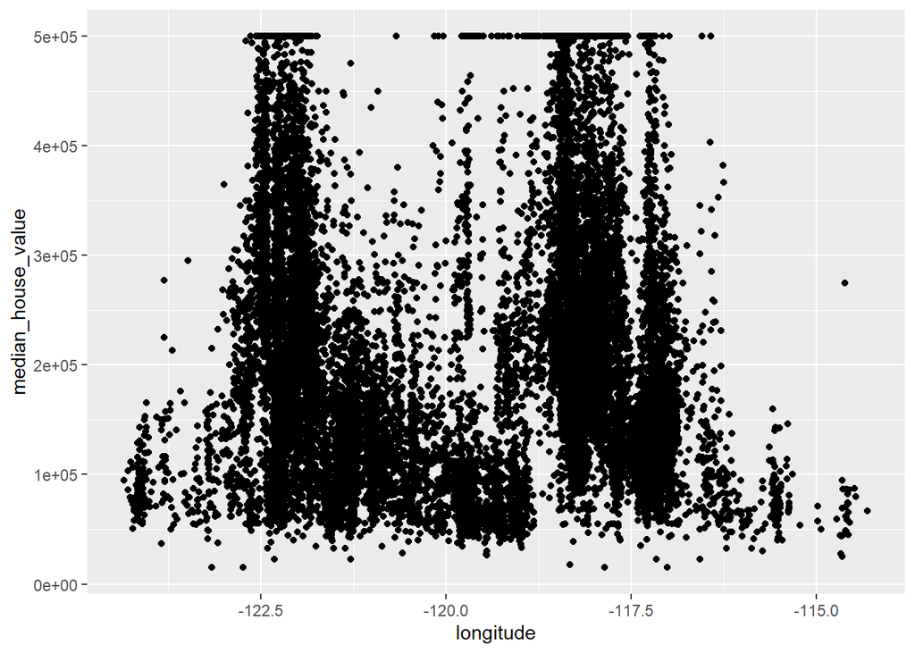

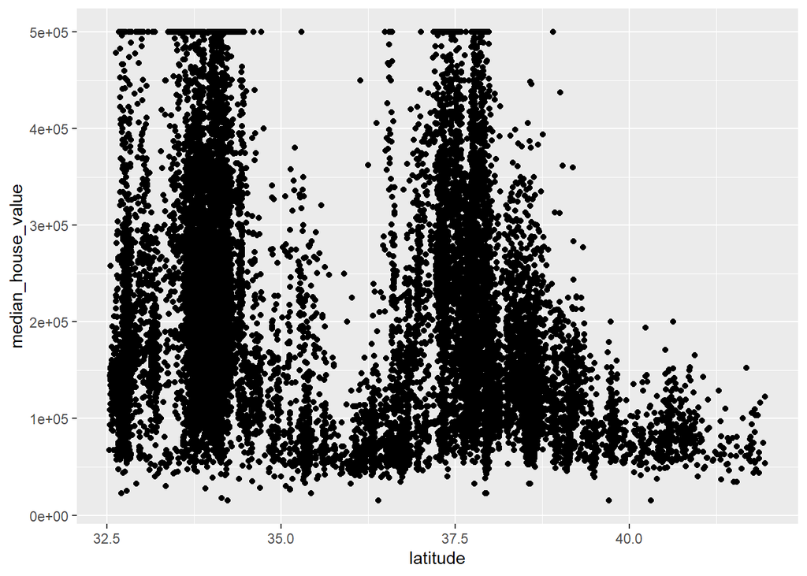

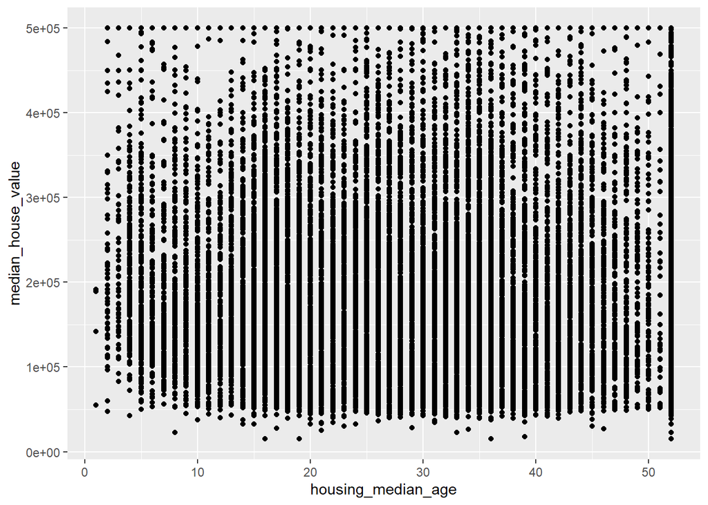

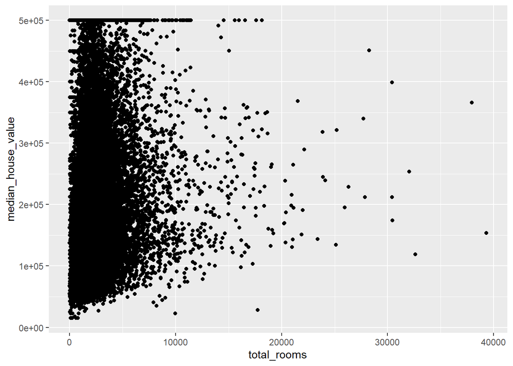

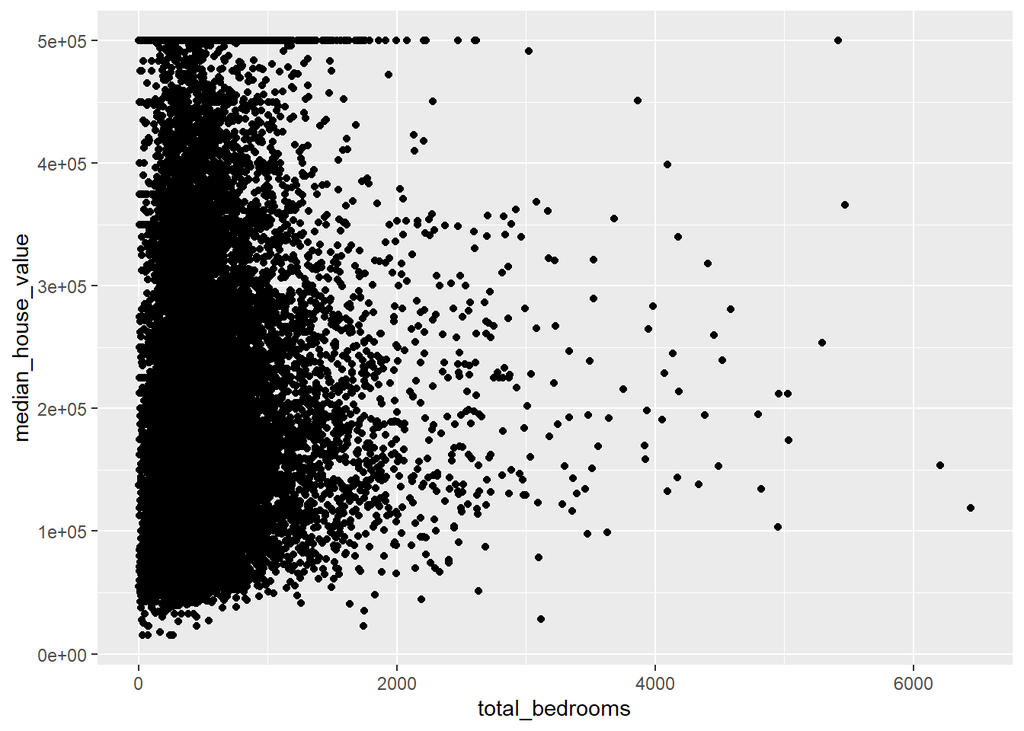

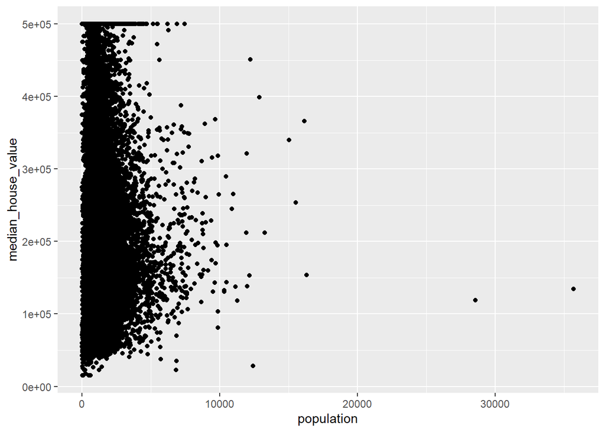

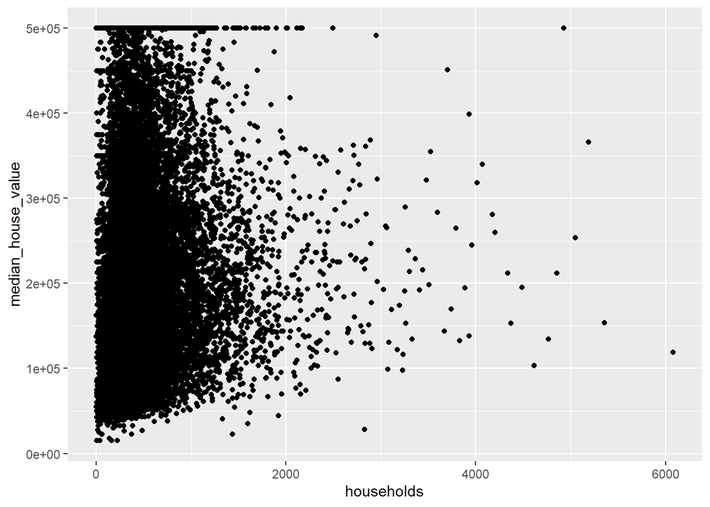

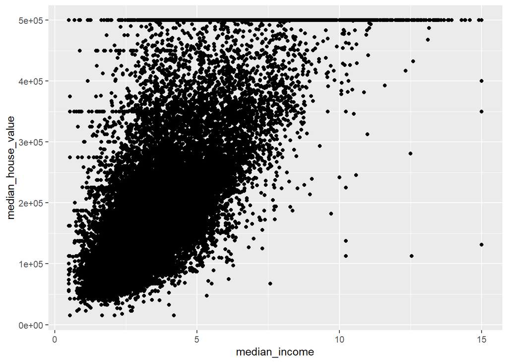

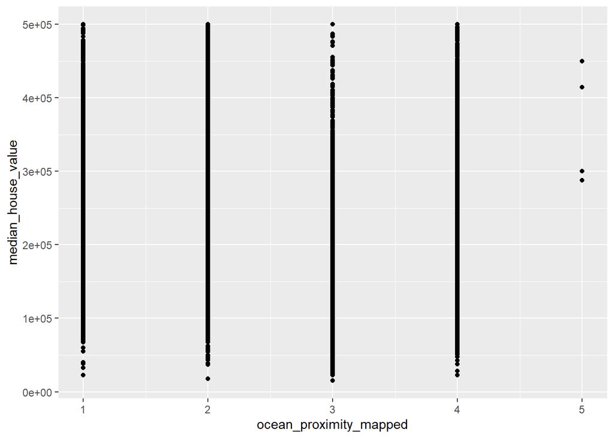

```r
colnames <- colnames(rhm_numeric)


for (colname in colnames){
  if( colname != "median_house_value"){
      plot<-ggplot(rhm_numeric,aes_string(colname,"median_house_value")) + geom_point()
      print(plot)
  }
}
```